# GISC 7360SP 2020 Lab04

Yalin Yang

2020-04-15

# Lab04: Regression Kriging

## Part I: Trend Surface Model (8 points)

### Task 01:

You may use the script SampleByClick.r to pick manually in total 100 sample points. Alternatively, use your favorite GIS program. This task requires careful planning and perhaps a nested sampling strategy. The predictive quality of your model very much depends on the selected sample points. (2 points)

Clearly justify your selection strategies of sample points based on the criteria listed below: (2 points)

```r
rm(list=ls(all=TRUE))
library(maptools); library(RColorBrewer)
setwd("G:\\UTD_Classes\\2020Spring\\GISC7360_Pattern_Analysis\\Lecture05\\KansasDEM")

# read the DEM shapefile
gridDEM <- rgdal::readOGR(dsn=getwd(), layer="DEMPointsDisRiv", integer64="warn.loss")
proj4string(gridDEM)
```

```
[1] "+proj=utm +zone=14 +datum=WGS84 +units=m +no_defs +ellps=WGS84 +towgs84=0,0,0"
```

```r
boxDEM <- bbox(gridDEM)
cat("Latitude range: ",boxDEM[1,2] - boxDEM[1,1],"\n")
```

```
Latitude range:  299977.1
```

```r
cat("Longitude range: ",boxDEM[2,2] - boxDEM[2,1],"\n")
```

```
Longitude range:  194624.3
```

```r
river <- rgdal::readOGR(dsn=getwd(), layer="RiversRevised", integer64="warn.loss")
proj4string(river)
```

```
[1] "+proj=utm +zone=14 +datum=WGS84 +units=m +no_defs +ellps=WGS84 +towgs84=0,0,0"
```

```r
grid.data <- as.data.frame(gridDEM)
summary(grid.data)
```

```
       ID           LONGITUDE             LATITUDE          ELEVATION       RIVERDIST         coords.x1        coords.x2
 Min.   :  5625   Min.   :-100754598   Min.   :38179178   Min.   :347.0   Min.   : 0.0000   Min.   :346321   Min.   :4225696
 1st Qu.:178025   1st Qu.: -99896236   1st Qu.:38612512   1st Qu.:482.0   1st Qu.: 0.8989   1st Qu.:422193   1st Qu.:4274178
 Median :350425   Median : -99037872   Median :39045844   Median :579.0   Median : 2.0974   Median :496701   Median :4322778
 Mean   :350425   Mean   : -99040060   Mean   :39047894   Mean   :603.3   Mean   : 2.7686   Mean   :496530   Mean   :4322563
 3rd Qu.:522825   3rd Qu.: -98179500   3rd Qu.:39479178   3rd Qu.:713.0   3rd Qu.: 3.9510   3rd Qu.:570897   3rd Qu.:4370915
 Max.   :695225   Max.   : -97321134   Max.   :39920844   Max.   :920.0   Max.   :17.0884   Max.   :646298   Max.   :4420320
```

**Plot DEM**

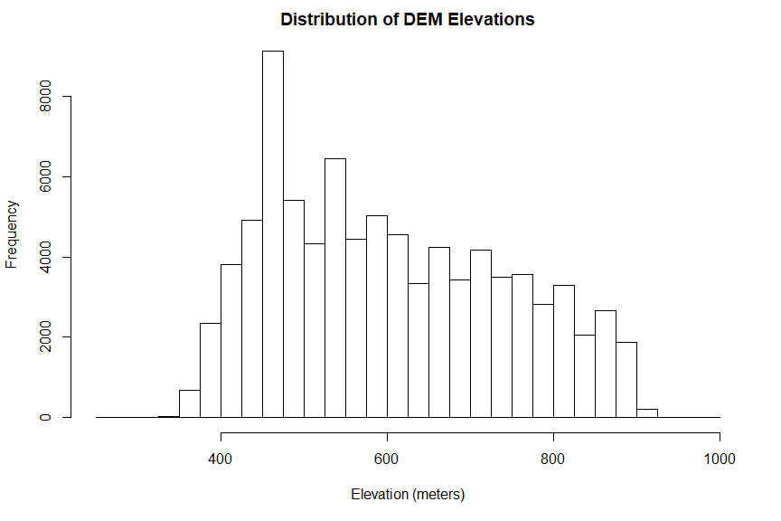

```r
breakpts <- seq(250,1000,by=25)                                                 # Define Elevation classes
hist(grid.data$ELEVATION, breaks=breakpts,
     xlab="Elevation (meters)", main="Distribution of DEM Elevations")          # Check Distribution
```

```r
# lines(density(grid.data$ELEVATION), lwd = 2, col = "chocolate3")                # density plot
ncl <- length(breakpts)-1                                                       # Number of classes
pal <- terrain.colors(ncl)                                                      # get colors
cols <- pal[findInterval(grid.data$ELEVATION,breakpts,rightmost.closed=T)]      # assign appropriate color to each residual
```

#### Q1

You want to avoid any bias in the predicted surface. Therefore, the average predicted elevations should match closely the average observed elevations in the study area. *How can you try to avoid this potential bias? (average should be equal)*

Since we want to avoid the bias of selecting sample points, at first, we could evenly distribute 72 points (6 rows * 12 columns) based on the DEM boundary.

#### Q2

The extrapolation problem should be avoided and the prediction error, in particular at the edges of the study area, need to be minimized. *How many sample points should be assign to control for this problem?*

Since the trend surface could only solve the problem of interpolation instead of extrapolation, we place 32 points(6*2 + 12* 2 - 4) across the boundary.

**Pick up Sample Points**

```r
library(raster)
# Place 72 Sample Points evenly in the map

range <- floor(boxDEM[,2]) - ceiling(boxDEM[,1])
coords.x1 <- seq(ceiling(boxDEM[1,1]), floor(boxDEM[1,2]),length.out = 12)
coords.x2 <- seq(ceiling(boxDEM[2,1]), floor(boxDEM[2,2]),length.out = 6)
samplePoints <- as.data.frame(expand.grid(coords.x1,coords.x2))
samplePoints <- SpatialPoints(samplePoints)
samplePoints@proj4string <- gridDEM@proj4string
```

```r
library(rgeos)
elevation <- c()
riveDist <- c()
for (i in 1:72){
  index <- which.min(gDistance(samplePoints[i,],gridDEM, byid=TRUE))
  elevation <- c(elevation,grid.data$ELEVATION[index])
  riveDist <- c(riveDist,grid.data$RIVERDIST[index])
}
samplePoints$ELEVATION <- elevation
samplePoints$RIVERDIST <- riveDist
```

#### Q3

The rapid topographic variation along a transection of the river valleys and ridges needs to be captured properly. *How many sample points should be assigned to model this variability, where should they be placed and which variable in the data set measures it?*

By comparing the distribution of the distance from rivers to DEM points with the distribution of selected sample points, we place an extra 20 points to the range that has a different proportion according to the origin data.

**Select 20 Points within the reasonable River edge area**

```r
summary(samplePoints$RIVERDIST)
```

```
   Min. 1st Qu.  Median    Mean 3rd Qu.    Max.
 0.0242  0.8120  2.4194  3.0993  4.5191 15.0033
```

```r
summary(gridDEM$RIVERDIST)
```

```
   Min. 1st Qu.  Median    Mean 3rd Qu.    Max.
 0.0000  0.8989  2.0974  2.7686  3.9510 17.0884
```

```r
library(maptools)
# Keep the Same Range

index <- c()

# Add Max and Min value
index <- c(index,which.min(gridDEM$RIVERDIST))
index <- c(index,which.max(gridDEM$RIVERDIST))

# Correct the quartile distribution
set.seed(1250)

# 8 from min to 1st quantile
index <- c(index,sample(which(gridDEM$RIVERDIST < quantile(gridDEM$RIVERDIST,0.25)),8))

# 5 from 1st quantile to mean
index <- c(index,sample(which(gridDEM$RIVERDIST < mean(gridDEM$RIVERDIST) & gridDEM$RIVERDIST > quantile(gridDEM$RIVERDIST,0.25)),5))

# 2 from mean to 3rd quantile
index <- c(index,sample(which(gridDEM$RIVERDIST > mean(gridDEM$RIVERDIST) & gridDEM$RIVERDIST < quantile(gridDEM$RIVERDIST,0.75)),2))

# 3 nearest to the mean
diff_mean <- sort(abs(gridDEM$RIVERDIST-mean(gridDEM$RIVERDIST)),decreasing = F)
index <- c(index,which(abs(gridDEM$RIVERDIST-mean(gridDEM$RIVERDIST)) == diff_mean[1]))
index <- c(index,which(abs(gridDEM$RIVERDIST-mean(gridDEM$RIVERDIST)) == diff_mean[2]))
index <- c(index,which(abs(gridDEM$RIVERDIST-mean(gridDEM$RIVERDIST)) == diff_mean[3]))

sample_river <-  SpatialPoints(data.frame(gridDEM@coords[index,1],gridDEM@coords[index,2]))
sample_river@proj4string <- gridDEM@proj4string
sample_river$ELEVATION <- gridDEM$ELEVATION[index]
sample_river$RIVERDIST <- gridDEM$RIVERDIST[index]
samplePoints <- spRbind(samplePoints,sample_river)
```

```r
summary(samplePoints$ELEVATION)
```

```
   Min. 1st Qu.  Median    Mean 3rd Qu.    Max.
  366.0   469.0   576.0   603.3   714.5   914.0
```

```r
summary(gridDEM$ELEVATION)
```

```
   Min. 1st Qu.  Median    Mean 3rd Qu.    Max.
  347.0   482.0   579.0   603.3   713.0   920.0
```

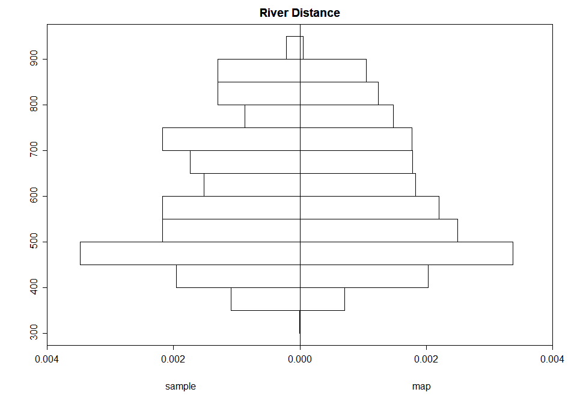

```r
riveDist <- Hmisc::histbackback(samplePoints$ELEVATION, gridDEM$ELEVATION,
                                prob=TRUE, xlab=c("sample","map"),
                                main="River Distance")
```

```r
NA
NA
```

** Select last 8 points to keep those two distribution with same mean**

```r
## Keep the same range of elevation

index <- c()

set.seed(1250)
# Add Max and Min value (2)
index <- c(index,which.min(gridDEM$ELEVATION))
index <- c(index,which.max(gridDEM$ELEVATION))

# 1 from the 1st quantile
index <- c(index,sample(which(gridDEM$ELEVATION < quantile(gridDEM$ELEVATION,0.25)),1))

# 1 from the 3st quantile
index <- c(index,sample(which(gridDEM$ELEVATION > mean(gridDEM$ELEVATION) & gridDEM$ELEVATION < quantile(gridDEM$ELEVATION,0.75)),1))

# 4 nearest to the mean
diff_mean <- sort(abs(gridDEM$ELEVATION-mean(gridDEM$ELEVATION)),decreasing = F)
index <- c(index,sample(which(abs(gridDEM$ELEVATION-mean(gridDEM$ELEVATION)) == diff_mean[1]),4))


sample_dem <-  SpatialPoints(data.frame(gridDEM@coords[index,1],gridDEM@coords[index,2]))
sample_dem@proj4string <- gridDEM@proj4string
sample_dem$ELEVATION <- gridDEM$ELEVATION[index]
sample_dem$RIVERDIST <- gridDEM$RIVERDIST[index]
samplePoints <- spRbind(samplePoints,sample_dem)
```

**t test**

```r
t.test(samplePoints$ELEVATION, gridDEM$ELEVATION)
```

```
    Welch Two Sample t-test

data:  samplePoints$ELEVATION and gridDEM$ELEVATION
t = -0.035363, df = 99.197, p-value = 0.9719
alternative hypothesis: true difference in means is not equal to 0
95 percent confidence interval:
 -30.58878  29.51753
sample estimates:
mean of x mean of y
 602.7500  603.2856
```

#### Q4

In order to build a well-defined variogram all spatial scales of the inter-sample point distances need to be represented. *How many sample points should be assigned to fill in missing distance ranges and where should these points be placed?*

In order to build a well-defined variogram, the inter-sample point distance should be in variety. we place multiple points within each quantile range from the original data, it should be enough to simulate the relationship between different distance. Also, we place plenty enough points near to the average elevation, which could be used for modeling the relationship with small inter-distance.

**Finally, show the map of your sampling points and the given elevations similar to the map shown above.**

```r
plot(gridDEM, axes=T, col=cols, pch=15,cex=1)                                   # Observed DEM Grid
plot(river,col="blue",add=T)
```

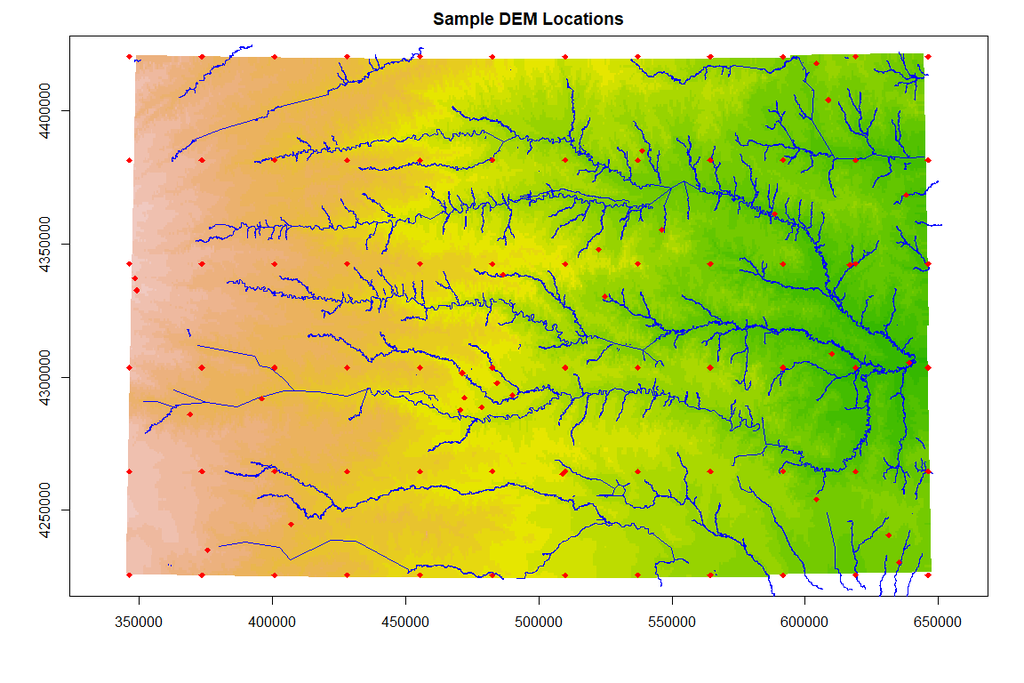

```r
points(samplePoints,col= "Red",pch = 18)
title("Sample DEM Locations")
```

### Task 02

Estimate the 1st, 2nd and 3rd order trend-surface models. Include the distance to the nearest rivers as covariable. (1 point)(determine which one is good using partial F test, using histogram to compare)

#### Transfer coordinates

```r
zTransCoord <- function(x,xmean,xsd,reverse=F){
  if (reverse == F) x <- (x-xmean)/xsd
  else x <- x*xsd+xmean
  return(x)
} #end:zTransCoord

yMean <- mean(samplePoints@coords[,2]); xMean <- mean(samplePoints@coords[,1])
ySd <- sd(samplePoints@coords[,2]); xSd <- sd(samplePoints@coords[,1])

samplePoints$X <- zTransCoord(samplePoints@coords[,1],xMean,xSd)
samplePoints$Y <- zTransCoord(samplePoints@coords[,2],yMean,ySd)
gridDEM$X <- zTransCoord(gridDEM$coords.x1,xMean,xSd)
gridDEM$Y <- zTransCoord(gridDEM$coords.x2,yMean,ySd)
```

```r
makeTrendPolyForm <- function(baseForm=Z~1, coordForm=~X+Y, shpDf=NULL, polyDeg=1){
  if (missing(baseForm) || class(baseForm) != "formula") stop("'baseForm' missing or incorrect")
  if (missing(coordForm) || class(coordForm) != "formula" || length(all.vars(coordForm)) != 2)
      stop("'coordForm' missing or incorrect")
  if (as.integer(polyDeg) < 1L ) stop("'polyDeg' needs to be integer of 1 or above")
  ## shpDf declare check input variables
  if (!is.null(shpDf)){
    if (class(try(model.frame(baseForm, shpDf), T)) != "data.frame") stop("Incorrect variables in 'baseFrom'")
    if (class(try(model.frame(coordForm, shpDf), T)) != "data.frame") stop("Incorrect variables in 'coordFrom'")
  }
  ## Build string with the trend-surface coordinates
  expo <- expand.grid(0L:polyDeg, 0L:polyDeg)
  expo <- expo[rowSums(expo) <= polyDeg, ]    # make sure only terms up to polyDeg enter the formula
  expo <- expo[-1,]                           # exclude x^0*y^0
  expo <- expo[order(rowSums(expo)), ]        # make sure formula is sorted by the degree of the polynomial
  formStr <- "~ ."
  xy <- all.vars(coordForm)
  for (i in 1: nrow(expo)) {
    formStr <- paste(formStr, " + I(",xy[1],"^",expo[i,1],"*",xy[2],"^",expo[i,2],")", sep="")
  }
  ## Merge covariate and polynomial formulas
  polyForm <- update(baseForm,as.formula(formStr))

  return(polyForm)
} #end::makeTrendPolyForm
```

#### Fit 1stOrder TrendSurface

```r
polyForm1 <- makeTrendPolyForm(ELEVATION~RIVERDIST+I(RIVERDIST^2), ~X+Y, shpDf=samplePoints, polyDeg=1)
lmTrend1 <- lm(polyForm1, data=samplePoints)
summary(lmTrend1)
```

```
Call:
lm(formula = polyForm1, data = samplePoints)

Residuals:
    Min      1Q  Median      3Q     Max
-89.687 -20.641   2.741  18.312  72.271

Coefficients:
                Estimate Std. Error t value Pr(>|t|)
(Intercept)     578.0165     5.9427  97.264  < 2e-16 ***
RIVERDIST         9.4761     2.6866   3.527 0.000649 ***
I(RIVERDIST^2)   -0.1597     0.1819  -0.878 0.382211
I(X^1 * Y^0)   -133.8570     3.7746 -35.463  < 2e-16 ***
I(X^0 * Y^1)     -1.0224     3.2245  -0.317 0.751878
---
Signif. codes:  0 ‘***’ 0.001 ‘**’ 0.01 ‘*’ 0.05 ‘.’ 0.1 ‘ ’ 1

Residual standard error: 31.59 on 95 degrees of freedom
Multiple R-squared:  0.9582,    Adjusted R-squared:  0.9565
F-statistic: 544.7 on 4 and 95 DF,  p-value: < 2.2e-16
```

#### Fit 2nd Order TrendSurface

```r
polyForm2 <- makeTrendPolyForm(ELEVATION~RIVERDIST+I(RIVERDIST^2), ~X+Y, shpDf=samplePoints, polyDeg=2)
lmTrend2 <- lm(polyForm2, data=samplePoints)
summary(lmTrend2)
```

```
Call:
lm(formula = polyForm2, data = samplePoints)

Residuals:
    Min      1Q  Median      3Q     Max
-63.767 -14.560   1.144  20.923  55.274

Coefficients:
                Estimate Std. Error t value Pr(>|t|)
(Intercept)     556.3815     6.0494  91.973  < 2e-16 ***
RIVERDIST         8.3753     2.3280   3.598  0.00052 ***
I(RIVERDIST^2)   -0.2184     0.1623  -1.346  0.18168
I(X^1 * Y^0)   -135.9283     3.2044 -42.419  < 2e-16 ***
I(X^0 * Y^1)     -1.8714     2.7454  -0.682  0.49716
I(X^2 * Y^0)     16.5519     3.3531   4.936 3.54e-06 ***
I(X^1 * Y^1)     -2.9787     2.6568  -1.121  0.26513
I(X^0 * Y^2)      9.7981     2.9720   3.297  0.00139 **
---
Signif. codes:  0 ‘***’ 0.001 ‘**’ 0.01 ‘*’ 0.05 ‘.’ 0.1 ‘ ’ 1

Residual standard error: 26.65 on 92 degrees of freedom
Multiple R-squared:  0.9712,    Adjusted R-squared:  0.969
F-statistic: 443.3 on 7 and 92 DF,  p-value: < 2.2e-16
```

**Compare two models**

```r
anova(lmTrend1,lmTrend2)
```

```
Analysis of Variance Table

Model 1: ELEVATION ~ RIVERDIST + I(RIVERDIST^2) + I(X^1 * Y^0) + I(X^0 *
    Y^1)
Model 2: ELEVATION ~ RIVERDIST + I(RIVERDIST^2) + I(X^1 * Y^0) + I(X^0 *
    Y^1) + I(X^2 * Y^0) + I(X^1 * Y^1) + I(X^0 * Y^2)
  Res.Df   RSS Df Sum of Sq      F    Pr(>F)
1     95 94794
2     92 65332  3     29462 13.829 1.613e-07 ***
---
Signif. codes:  0 ‘***’ 0.001 ‘**’ 0.01 ‘*’ 0.05 ‘.’ 0.1 ‘ ’ 1
```

#### Fit 3rd Order TrendSurface

```r
polyForm3 <- makeTrendPolyForm(ELEVATION~RIVERDIST, ~X+Y, shpDf=samplePoints, polyDeg=3)
lmTrend3 <- lm(polyForm3, data=samplePoints)
summary(lmTrend3)
```

```
Call:
lm(formula = polyForm3, data = samplePoints)

Residuals:
    Min      1Q  Median      3Q     Max
-43.705 -15.858   0.007  16.947  45.443

Coefficients:
             Estimate Std. Error t value Pr(>|t|)
(Intercept)   561.285      4.899 114.579  < 2e-16 ***
RIVERDIST       5.107      1.087   4.698 9.51e-06 ***
I(X^1 * Y^0) -154.058      7.275 -21.176  < 2e-16 ***
I(X^0 * Y^1)   -8.077      7.016  -1.151 0.252731
I(X^2 * Y^0)   16.073      2.971   5.410 5.25e-07 ***
I(X^1 * Y^1)   -3.130      2.402  -1.303 0.195837
I(X^0 * Y^2)   10.244      2.651   3.864 0.000212 ***
I(X^3 * Y^0)    2.361      3.799   0.621 0.535862
I(X^2 * Y^1)   -1.625      2.855  -0.569 0.570716
I(X^1 * Y^2)   12.381      2.646   4.680 1.02e-05 ***
I(X^0 * Y^3)    3.923      3.234   1.213 0.228344
---
Signif. codes:  0 ‘***’ 0.001 ‘**’ 0.01 ‘*’ 0.05 ‘.’ 0.1 ‘ ’ 1

Residual standard error: 24.15 on 89 degrees of freedom
Multiple R-squared:  0.9771,    Adjusted R-squared:  0.9745
F-statistic: 380.1 on 10 and 89 DF,  p-value: < 2.2e-16
```

**Check the multicollinearity**

```r
car::vif(lmTrend3)
```

```
   RIVERDIST I(X^1 * Y^0) I(X^0 * Y^1) I(X^2 * Y^0) I(X^1 * Y^1) I(X^0 * Y^2) I(X^3 * Y^0) I(X^2 * Y^1) I(X^1 * Y^2) I(X^0 * Y^3)
    2.045262     8.982872     8.355686     1.177689     1.010799     1.045307     8.991924     2.490382     2.319687     7.237529
```

**Compare models**

```r
anova(lmTrend2,lmTrend3)
```

```
Analysis of Variance Table

Model 1: ELEVATION ~ RIVERDIST + I(RIVERDIST^2) + I(X^1 * Y^0) + I(X^0 *
    Y^1) + I(X^2 * Y^0) + I(X^1 * Y^1) + I(X^0 * Y^2)
Model 2: ELEVATION ~ RIVERDIST + I(X^1 * Y^0) + I(X^0 * Y^1) + I(X^2 *
    Y^0) + I(X^1 * Y^1) + I(X^0 * Y^2) + I(X^3 * Y^0) + I(X^2 *
    Y^1) + I(X^1 * Y^2) + I(X^0 * Y^3)
  Res.Df   RSS Df Sum of Sq      F    Pr(>F)
1     92 65332
2     89 51914  3     13418 7.6681 0.0001291 ***
---
Signif. codes:  0 ‘***’ 0.001 ‘**’ 0.01 ‘*’ 0.05 ‘.’ 0.1 ‘ ’ 1
```

**According to the partial F-test result, the 3rd order model can be utilized as the optimal model.**

### Task 03

Map the three predicted trend-surfaces. Use a meaningful color ramp. (1 point) (Sd distribution?)

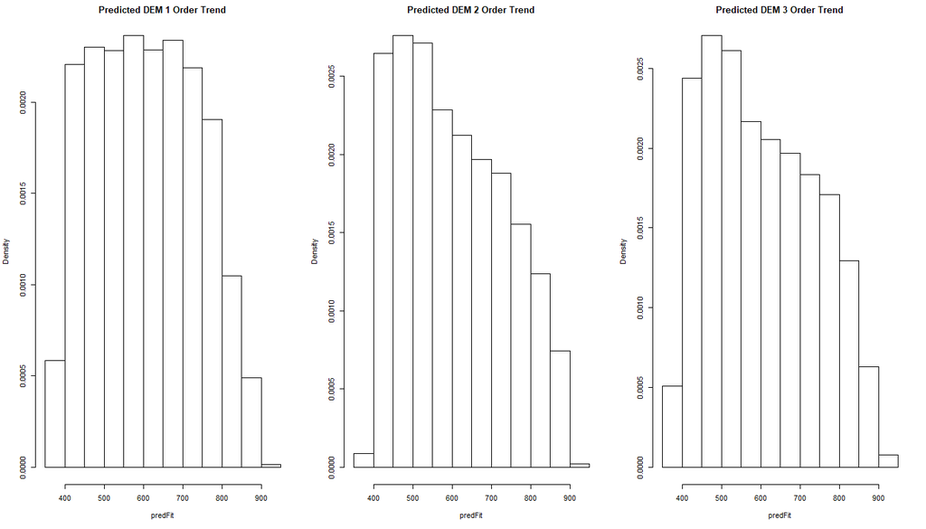

```r
par(mfrow = c(1,3))
model_lst = list(lmTrend1,lmTrend2,lmTrend3)

break_lst <- list()
for (i in 1:3){
  predTrend <- predict(model_lst[[i]], gridDEM, se.fit = TRUE)
  predFit <- predTrend$fit
  predHist <- hist(predFit,freq=F,main= paste("Predicted DEM",i,"Order Trend"))
  break_lst[[i]] <- predHist$breaks
}
```

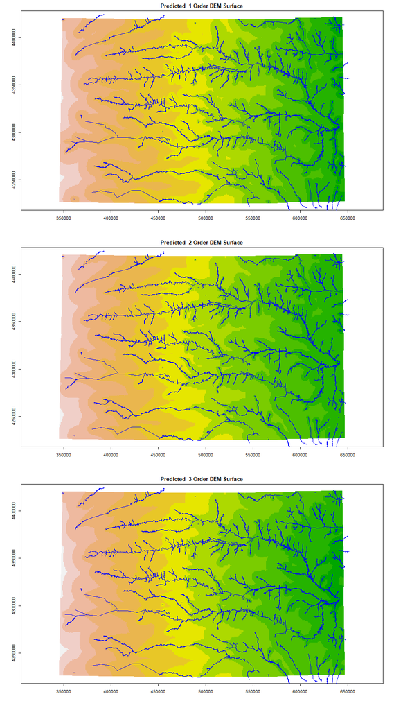

```r
par(mfrow = c(3,1))

for (i in 1:3){
  predTrend <- predict(model_lst[[i]], gridDEM, se.fit = TRUE)
  predFit <- predTrend$fit
  breakptsPred <- break_lst[[i]]
  nclPred <- length(breakptsPred)-1                                                   # Number of classes
  palPred <- terrain.colors(nclPred)                                                  # get colors
  colsPred <- palPred[findInterval(predFit,
                                 breakptsPred,rightmost.closed=T)]                    # assign appropriate color to each residual

  plot(gridDEM, axes=T, col=colsPred, pch=15,cex=1)
  plot(river,col="blue",add=T)
  title(paste("Predicted ", i, "Order DEM Surface"))
}
```

### Task 04

Decide with the partial F-test, which of the three surface models is most appropriate for your given sample points. Interpreted the selected trend-surface regression model. (1 point)

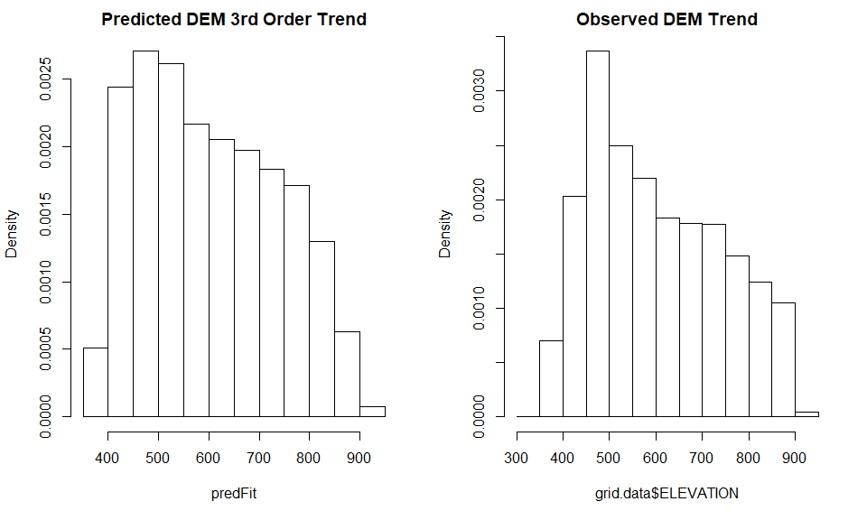

```r
par(mfrow = c(1,2))

predTrend3 <- predict(lmTrend3, gridDEM, se.fit = TRUE)
predFit <- predTrend3$fit
predHist <- hist(predFit,freq=F,main="Predicted DEM 3rd Order Trend")
originHist <- hist(grid.data$ELEVATION,freq=F,main="Observed DEM Trend")
```

```r
obsElev <- gridDEM$ELEVATION
plot(obsElev,predFit,pch=".")  ## note granularity of observed elevation
title(main="Observed against Predicted Elevations")
```

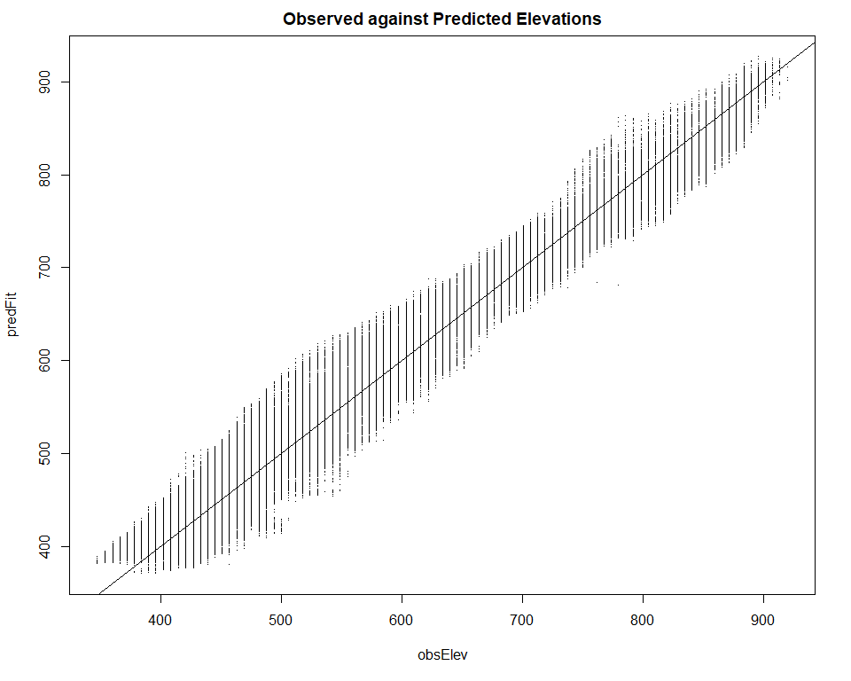

```r
abline(a=0,b=1)
```

```r
summary(predFit)
```

```
   Min. 1st Qu.  Median    Mean 3rd Qu.    Max.
  371.0   486.1   589.9   604.1   714.6   927.3
```

```r
summary(grid.data$ELEVATION)
```

```
   Min. 1st Qu.  Median    Mean 3rd Qu.    Max.
  347.0   482.0   579.0   603.3   713.0   920.0
```

```r
e1071::skewness(predFit) ; e1071::skewness(grid.data$ELEVATION)
```

```
[1] 0.2773491
[1] 0.3372247
```

```r
e1071::kurtosis(predFit) ; e1071::kurtosis(grid.data$ELEVATION)
```

```
[1] -1.032655
[1] -0.982027
```

```r
t.test(predFit,grid.data$ELEVATION)
```

```
    Welch Two Sample t-test

data:  predFit and grid.data$ELEVATION
t = 1.2977, df = 172237, p-value = 0.1944
alternative hypothesis: true difference in means is not equal to 0
95 percent confidence interval:
 -0.4408866  2.1685812
sample estimates:
mean of x mean of y
 604.1495  603.2856
```

According to the partial F-test result, the 3rd order model can be utilized as the optimal model. From the t-test, the predicted value has the same average to the observed elevation. And both of those two distributions have similar skewness and kurtosis trend.

### Task 05

Evaluate the prediction quality of your most appropriate trend surface model. Does the histogram of observed elevations match that based on the predicted values? Does your prediction model lead to biased overall elevation estimates? If yes, what may be the cause? (1 point)

From the histogram provided in task 3, the observed distribution has a longer tail around the elevation within 800 - 900 meters. The result of skewness also proves that the observed value is more positively skewed. And the predicted value is more evenly distributed according to the kurtosis. Both of those two difference indicates that our model is over smoothed than the observed. Since our model simulating the global trend and ignores some local trends with rapid change.

### Task 06

For your most appropriate model, map the **standard errors** of the prediction surfaces. Use a meaningful color ramp. Interpret the general pattern in the standard errors. In particular evaluate the standard errors at the edges of the study area relative to those in the center? (1 point)

```r
library(classInt)
predSe.3 <- predTrend3$se.fit
n.col <- 6
pal <- brewer.pal(n.col,"Oranges")
seClass <- classIntervals(predSe.3, n.col, style="equal")
seCol <- findColours(seClass,pal)
plot(gridDEM,axes=T,col=seCol,pch=15,cex=2,
main="Prediction Standard Error: 3rd Order Trendsurface")
plot(river,col="blue",add=T)
```

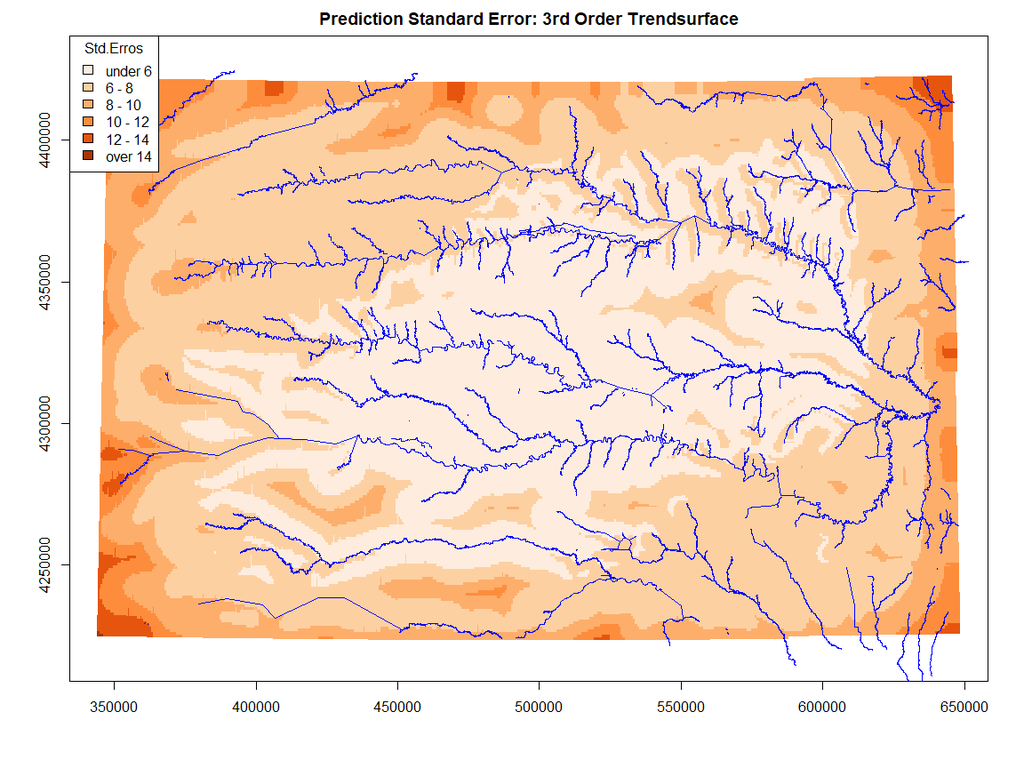

```r
legend("topleft", title = "Std.Erros",
legend = leglabs(round(seClass$brks, digits = 0)), fill = pal, bty = "o", ncol = 1)
```

The central part of the study area has the smallest standard errors. With the distance closer to the edges of the study area, standard errors tend to be larger, and the four corners of the study area have the largest standard errors

### Task 07

For your most appropriate model, calculate the error component (residual surface: observed DEM minus predicted trend DEM). Map this pattern with a bipolar map theme (zero is the neutral value) and overlay the river network onto your residual map. Interpret this residual pattern. (1 point)

```r
pred.res <- gridDEM$ELEVATION-predTrend3$fit
n.col <- 5
pal <- rev(brewer.pal(n.col,"RdBu"))
seClass <- classIntervals(pred.res, n.col, style="equal")
seCol <- findColours(seClass,pal)
plot(gridDEM,axes=T,col=seCol,pch=15,cex=2,main="3rd Order Trend residual surface")
plot(river,col="blue",add=T)
```

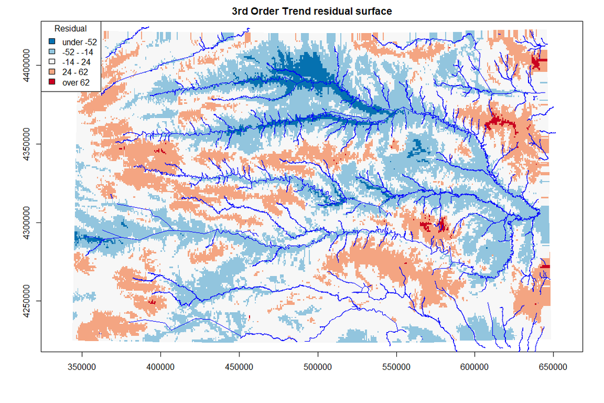

```r
legend("topleft", title = "Residual",
legend = leglabs(round(seClass$brks, digits = 0)), fill = pal,bty = "o", ncol = 1)
```

Since elevation decrease rapidly when close to rivers, we found there are sever overestimating problems that exist within those areas. In contrast, the elevation of areas along the mountain ridge is underestimating. This phenomenon indicates a strong spatial autocorrelation exists in residuals.

## Part II: Variogram Estimation (2 points)

### Task 08

Estimate the variogram function based on the error component at the sampling locations from Part I. Show the necessary plots and interpret them by exploring possible anisotropy, range, sill and nugget effects.

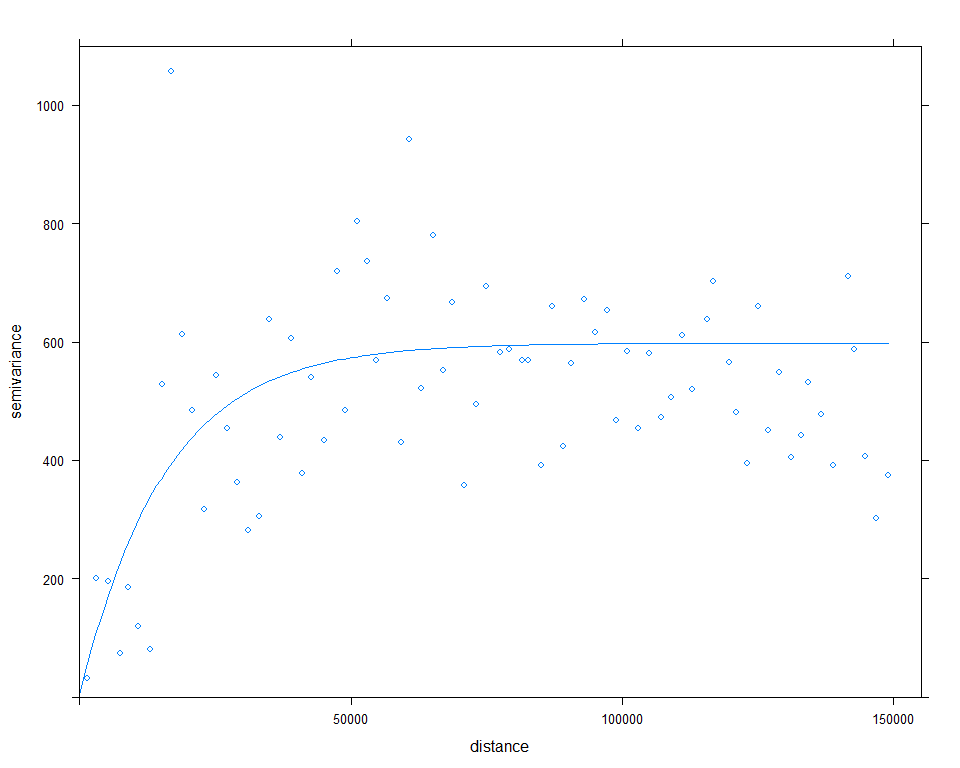

```r
library(gstat)
samplePoints$sampleRes <- residuals(lmTrend3)     # add residuals to sampleDEM
gPred <- gstat(id="simKrig", formula=sampleRes~1, beta=0, data=samplePoints)

## Select final variogram for simple kriging of residuals
varioFinal <- variogram(gPred, cutoff=150000, width=2000) # alternative: variogram(sampleRes~1,sampleDEM)
varioFit <- fit.variogram(varioFinal,model=vgm(model="Mat",range=150000,nugget=50))
plot(varioFinal,model=varioFit)
```

```r
varioFit
```

|  | model | psill | range | kappa |
| --- | --- | --- | --- | --- |
| 1 | Nug | 2.885286 | 0.00 | 0.0 |
| 2 | Mat | 595.178562 | 15744.19 | 0.5 |

```r
cat("Global variance is",var(samplePoints$sampleRes))
```

```
Global variance is 524.3819
```

## Part III: Kriging Interpolation of the error component (3 points)

### Task 09

Predict the error component by Kriging for all locations. Justify your choice of the Kriging model. Map the surface of the predicted error component with an appropriate color ramp. (1.5 point)

```r
## Predict the residuals
gPred <- gstat(id="simKrig",gPred, model=varioFit)
predSimKrig <- predict(gPred, model=varioFit, newdata=gridDEM) # alternative: krige(sampleRes~1,sampleDEM, gridDEM, model=varioFit)
```

```
[using simple kriging]
```

```r
## Predicted Kriging residuals
predRes <- predSimKrig$simKrig.pred      # Kriging cell residual prediction
```

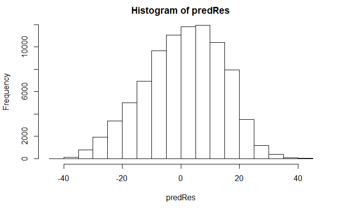

```r
hist(predRes)
```

```r
biPolarColorRamp <- function(varName,pos.breaks=4,neg.breaks=pos.breaks) {
  require(RColorBrewer); require(classInt)
  ## define breaks and color assignment
  q.neg.breaks <- classIntervals((varName[varName < 0]), n=neg.breaks, style="quantile")
  q.pos.breaks <- classIntervals((varName[varName > 0]), n=pos.breaks, style="quantile")
  qBreaks <- c(q.neg.breaks$brks[-(neg.breaks+1)],0,q.pos.breaks$brks[-1])     # combine neg and pos over zero

  pal.neg <- brewer.pal(neg.breaks, "Blues")
  pal.pos <- brewer.pal(pos.breaks, "Reds")
  colPal <- c(rev(pal.neg),pal.pos)                                                # combine palettes

  mapCol <- colPal[findInterval(varName,qBreaks,rightmost.closed=T)]
  return(list(mapCol=mapCol,qBreaks=qBreaks,colPal=colPal))
} # end:biPolarColorRamp
```

**Map Kriging residuals**

```r
library(RColorBrewer)
colRamp <- biPolarColorRamp(predRes, pos.breaks=4)
plot(gridDEM, axes=T, col=colRamp$mapCol, pch=15, cex=1)
plot(river,col="blue",add=T)
```

```r
plot(samplePoints,col="green",add=T)
legend("topright", title="Residuals", legend=leglabs(round(colRamp$qBreaks,2)),
       fill=colRamp$colPal, bg="white",ncol=1)
```

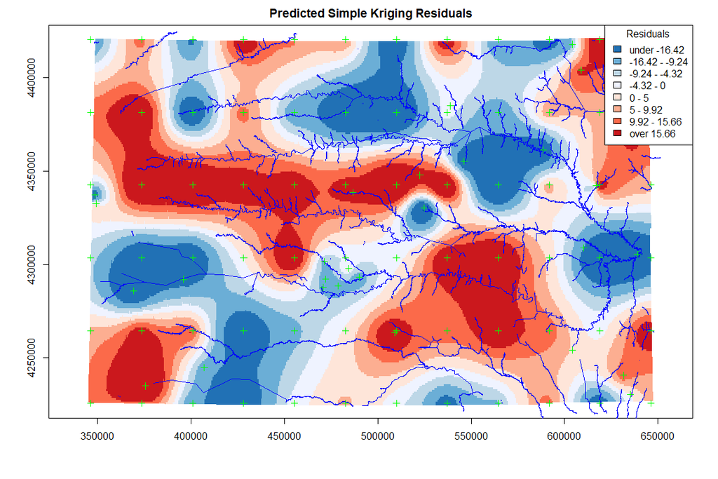

```r
title("Predicted Simple Kriging Residuals")
```

Simple Kriging was used in our plot because the mean value of the residual surface is known. After the 1st component has been removed in the dataset by the 3rd order trend surface, the mean value of residuals should be 0.

### Task 10

Estimate the uncertainty of the error component for all locations. Map the uncertainty surface with an appropriate color ramp. (1.5 point)

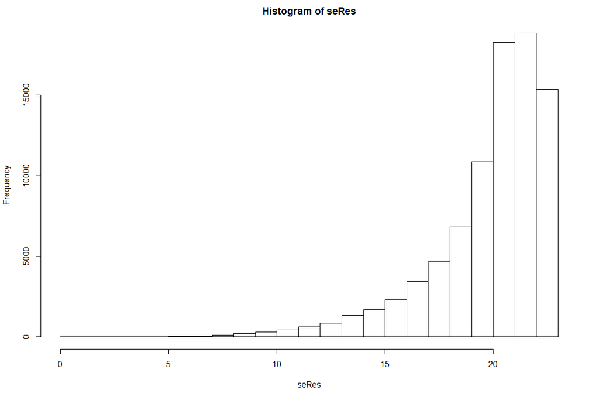

```r
## Map kriging prediciton standard error
seRes <- sqrt(predSimKrig$simKrig.var)       # Standard errors of Kriging Residuals

seHist<- hist(seRes)
```

```r
breakptsSe <- seHist$breaks
nclSe <- length(breakptsSe)-1
palSe <- rev(heat.colors(nclSe))
colsSe <- palSe[findInterval(seRes,
                             breakptsSe,rightmost.closed=T)]
plot(gridDEM, axes=T, col=colsSe, pch=15,cex=1)
plot(river,col="blue",add=T)
```

```r
plot(samplePoints,col="green",pch = 5,add=T)
legend("topright", title="Predicted DEM",legend=leglabs(round(breakptsSe,2)),
       fill=palSe,bg="white",ncol=1)
```

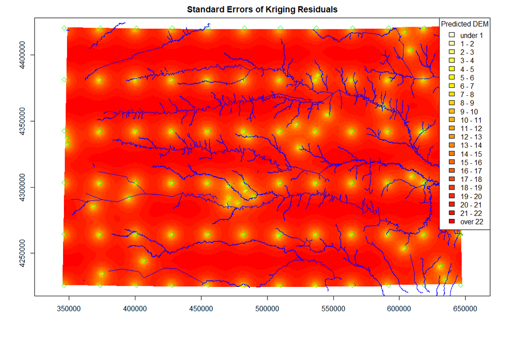

```r
title("Standard Errors of Kriging Residuals")
```

## Part IV: Combining Frist and Second Order Components (3 points)

### Task 11

Combine the predicted trend-surface with the predicted error component to obtain the overall predicted DEM surface. Map this predicted surface with a proper color ramp. (1 point)

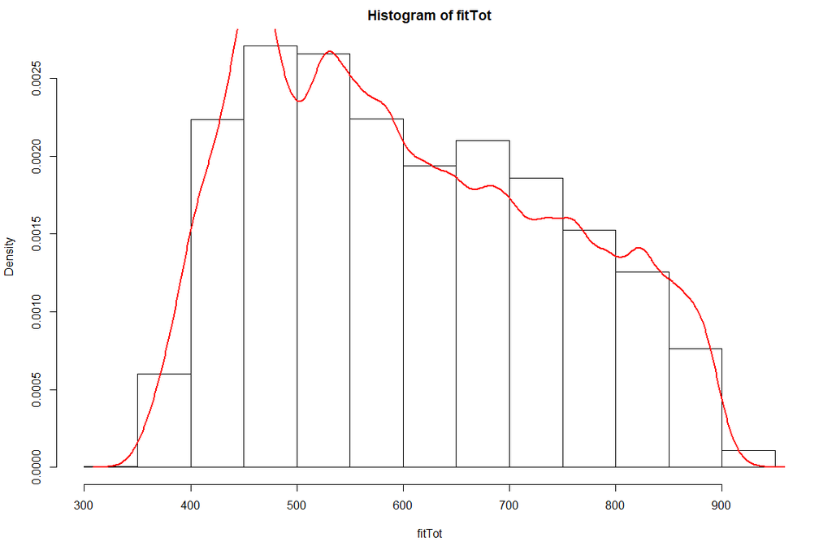

```r
fitTot <- predFit+predRes                          # Total predicted cell value
seTot <- sqrt(predSe.3^2+predSimKrig$simKrig.var)    # Total cell prediction standard error

## Map overall prediciton surface
fitHist<- hist(fitTot,freq=F)
lines(density(gridDEM$ELEVATION),col="red",lwd=2)
```

```r
breakptsFit <- fitHist$breaks
nclFit <- length(breakptsFit)-1
palFit <- terrain.colors(nclFit)
colsFit <- palFit[findInterval(fitTot,
                               breakptsFit,rightmost.closed=T)]
```

```r
plot(gridDEM, axes=T, col=colsFit, pch=15,cex=1)
plot(river,col="blue",add=T)
```

```r
plot(samplePoints,col="red",add=T)
legend("topright", title="Predicted DEM",legend=leglabs(round(breakptsFit,2)),
       fill=palFit,bg="white",ncol=1)
```

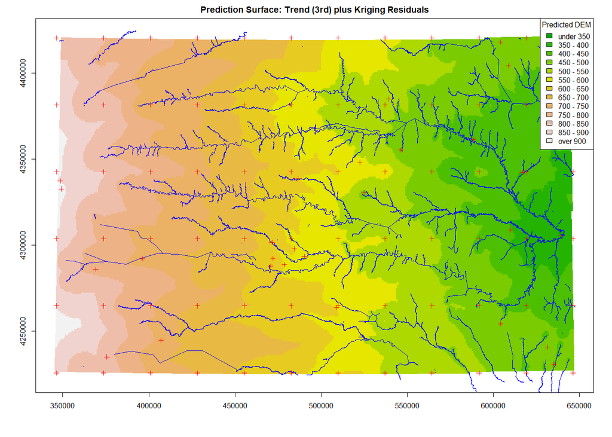

```r
title("Prediction Surface: Trend (3rd) plus Kriging Residuals")
```